# SCAP MODEL: STATISTICAL ANALYSIS AND PREDICTIVE MODELING

Nguyen Thai Pham, MD

2026-09-16

### 1. MULTIVARIABLE LOGISTIC REGRESSION (INITIAL 10-VARIABLE MODEL)

The following code establishes a multivariable logistic regression model with 10 potential risk factors. The statistical output (p-values, aOR, 95% CI) is utilized to screen for independent prognostic factors to build the reduced model.

```r
# Fit the initial multivariable logistic regression model
model_10_vars <- glm(GPB ~ dichkhutru + nguongtnm + nguongAIR +
                       nguongdkrt + nguongmt + dichtudo + hachviem +
                       Khitrong + nguongtuoi + Soitrong,
                     data = data_clean,
                     family = binomial)

# Extract model statistical summary
summary(model_10_vars)
```

```
##
## Call:
## glm(formula = GPB ~ dichkhutru + nguongtnm + nguongAIR + nguongdkrt +
##     nguongmt + dichtudo + hachviem + Khitrong + nguongtuoi +
##     Soitrong, family = binomial, data = data_clean)
##
## Coefficients:
##             Estimate Std. Error z value Pr(>|z|)
## (Intercept)  -4.3627     0.4885  -8.931  < 2e-16 ***
## dichkhutru    1.7447     0.3330   5.240 1.61e-07 ***
## nguongtnm     1.4787     0.3015   4.905 9.34e-07 ***
## nguongAIR     0.8991     0.2936   3.062   0.0022 **
## nguongdkrt    0.7690     0.3051   2.521   0.0117 *
## nguongmt      0.6161     0.2954   2.086   0.0370 *
## dichtudo      0.5671     0.2966   1.912   0.0559 .
## hachviem      0.5453     0.2966   1.838   0.0660 .
## Khitrong      0.6148     0.3292   1.868   0.0618 .
## nguongtuoi    0.3825     0.3088   1.239   0.2155
## Soitrong      0.2672     0.3049   0.876   0.3810
## ---
## Signif. codes:  0 '***' 0.001 '**' 0.01 '*' 0.05 '.' 0.1 ' ' 1
##
## (Dispersion parameter for binomial family taken to be 1)
##
##     Null deviance: 539.00  on 396  degrees of freedom
## Residual deviance: 316.86  on 386  degrees of freedom
## AIC: 338.86
##
## Number of Fisher Scoring iterations: 5
```

```r
# Estimate adjusted Odds Ratios (aOR) and 95% Confidence Intervals
exp(cbind(aOR = coef(model_10_vars), confint(model_10_vars)))
```

```
##                    aOR       2.5 %      97.5 %
## (Intercept) 0.01274372 0.004624081  0.03156916
## dichkhutru  5.72413078 3.028054434 11.23875506
## nguongtnm   4.38737245 2.438004396  7.97076741
## nguongAIR   2.45730672 1.383797944  4.38931256
## nguongdkrt  2.15755743 1.186967522  3.93868322
## nguongmt    1.85177909 1.038844715  3.31926934
## dichtudo    1.76309338 0.985952888  3.16518435
## hachviem    1.72517580 0.967022150  3.10439594
## Khitrong    1.84927099 0.972600765  3.54891231
## nguongtuoi  1.46597896 0.799952234  2.69502620
## Soitrong    1.30624402 0.717282238  2.37907422
```

### 2. REDUCED MODEL (SCAP SCORE) AND ROC CURVE ANALYSIS

Based on the initial multivariable analysis, 5 independent prognostic factors (p < 0.05) were retained: Localized periappendiceal fluid, Circumferential fat stranding, AIR score >= 7, Appendix diameter > 11.5 mm, and Cecal wall thickness > 7.2 mm. These variables construct the SCAP predictive model. The discriminative ability is evaluated using the Area Under the Receiver Operating Characteristic Curve (AUC).

```r
# Fit the reduced SCAP model (5 variables)
model_scap <- glm(GPB ~ dichkhutru + nguongtnm + nguongAIR +
                    nguongdkrt + nguongmt,
                  data = data_clean,
                  family = binomial)

# Estimate aOR and 95% CI for the reduced model
exp(cbind(aOR = coef(model_scap), confint(model_scap)))
```

```
##                    aOR      2.5 %      97.5 %
## (Intercept) 0.02866725 0.01289249  0.05803774
## dichkhutru  6.71567302 3.60839877 13.01073918
## nguongtnm   4.78372265 2.71564581  8.51324442
## nguongAIR   2.58782182 1.47736726  4.56088178
## nguongdkrt  2.45153264 1.42148870  4.24966164
## nguongmt    1.81094782 1.03432587  3.18039221
```

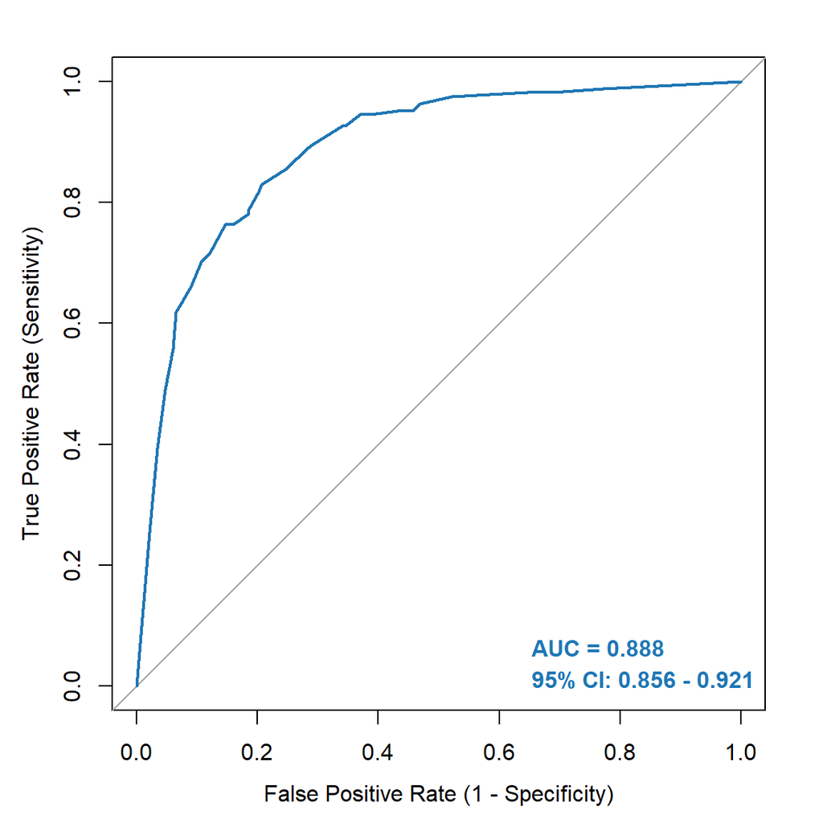

```r
# ROC Curve and AUC Calculation
library(pROC)

# Estimate predicted probabilities for each observation
prob_scap <- predict(model_scap, type = "response")

# Initialize ROC object and compute 95% CI for AUC
roc_scap <- roc(data_clean$GPB, prob_scap)
roc_ci <- ci(roc_scap)

# Configure numeric format for coordinate axes
options(scipen = 999)

# Visualize ROC Curve
plot(roc_scap,
     legacy.axes = TRUE,
     col = "#1f77b4",
     lwd = 2,
     xlab = "False Positive Rate (1 - Specificity)",
     ylab = "True Positive Rate (Sensitivity)")

# Extract and format AUC and 95% CI labels
auc_text <- sprintf("AUC = %.3f", roc_ci[2])
ci_text <- sprintf("95%% CI: %.3f - %.3f", roc_ci[1], roc_ci[3])

# Configure legend for the plot
legend("bottomright",
       legend = c(auc_text, ci_text),
       text.col = "#1f77b4",
       text.font = 2,
       bty = "n")
```

### 3. INTERNAL VALIDATION

To ensure the SCAP model is robust against overfitting and generalizable to new cohorts, internal validation was performed using two techniques: Bootstrap resampling (2000 iterations) and Leave-One-Out Cross-Validation (LOOCV).

```r
# Set random seed to ensure computational reproducibility
set.seed(2026)

# ==========================================
# 3.1. BOOTSTRAP VALIDATION (2000 REPLICATES)
# ==========================================
# Compute optimism-corrected 95% CI for AUC using 2000 bootstrap resamples
boot_auc <- ci.auc(roc_scap, method = "bootstrap", boot.n = 2000)

cat("--- BOOTSTRAP VALIDATION RESULTS (2000 REPLICATES) ---\n")
```

```
## --- BOOTSTRAP VALIDATION RESULTS (2000 REPLICATES) ---
```

```r
print(boot_auc)
```

```
## 95% CI: 0.8544-0.9204 (2000 stratified bootstrap replicates)
```

```r
# ==========================================
# 3.2. LEAVE-ONE-OUT CROSS-VALIDATION (LOOCV)
# ==========================================
n <- nrow(data_clean)
loocv_preds <- numeric(n)

# LOOCV Algorithm: Train the model n times, iteratively excluding 1 observation for validation
for (i in 1:n) {
  train_data <- data_clean[-i, ]
  test_data  <- data_clean[i, , drop = FALSE]

  # Fit the model on the training set
  fit_loocv <- glm(GPB ~ dichkhutru + nguongtnm + nguongAIR +
                     nguongdkrt + nguongmt,
                   data = train_data,
                   family = binomial)

  # Estimate predicted probability on the excluded observation
  loocv_preds[i] <- predict(fit_loocv, newdata = test_data, type = "response")
}

# Re-calculate AUC based on LOOCV predictions
roc_loocv <- roc(data_clean$GPB, loocv_preds)

cat("\n--- LOOCV RESULTS ---\n")
```

```
##
## --- LOOCV RESULTS ---
```

```r
cat("SCAP Model AUC after LOOCV:", round(auc(roc_loocv), 3), "\n")
```

```
## SCAP Model AUC after LOOCV: 0.869
```

### 4. MODEL CALIBRATION

The agreement between predicted probabilities and observed frequencies was evaluated using a calibration plot.

```r
# ==========================================
# 4. BOOTSTRAP CALIBRATION PLOT
# ==========================================
library(rms)

# Configure data environment for the rms package
dd <- datadist(data_clean)
options(datadist = "dd")

# Fit model using lrm function for calibration assessment
fit_rms <- lrm(GPB ~ dichkhutru + nguongtnm + nguongAIR +
                     nguongdkrt + nguongmt,
               data = data_clean,
               x = TRUE, y = TRUE)

# Perform calibration using 2000 bootstrap resamples
set.seed(2026)
cal <- calibrate(fit_rms, method = "boot", B = 2000)

# Adjust plot margins to optimize legend placement
par(mar = c(6, 5, 4, 2) + 0.1)

# Visualize calibration plot
plot(cal,
     lwd = 2,
     legend = FALSE,
     subtitles = FALSE, # Disable default lrm subtitles
     xlab = "Predicted Probability",
     ylab = "Observed Proportion",
     xlim = c(0, 1), ylim = c(0, 1))
```

```
##
## n=397   Mean absolute error=0.011   Mean squared error=0.0002
## 0.9 Quantile of absolute error=0.03
```

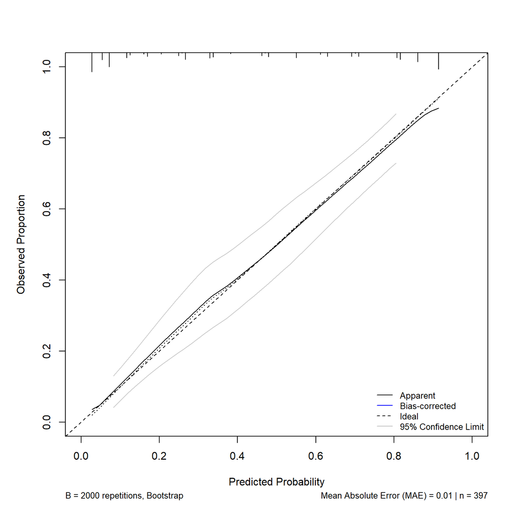

```r
# Configure legend
legend("bottomright",
       legend = c("Apparent",
                  "Bias-corrected",
                  "Ideal",
                  "95% Confidence Limit"),
       lty = c(1, 1, 2, 1),
       col = c("black", "blue", "black", "gray"),
       bty = "n", cex = 0.8)

# Integrate Bootstrap metrics (MAE and n) into the plot
mtext("B = 2000 repetitions, Bootstrap", side = 1, line = 4, adj = 0, cex = 0.8)
mtext(sprintf("Mean Absolute Error (MAE) = %.2f | n = %d",
              mean(abs(cal[,"predy"] - cal[,"calibrated.corrected"])),
              nrow(data_clean)),
      side = 1, line = 4, adj = 1, cex = 0.8)
```

```r
# ==========================================
# 5. RMSE AND F1-SCORE FROM LOOCV
# ==========================================
library(caret)

# Compute Root Mean Square Error (RMSE)
rmse_loocv <- sqrt(mean((data_clean$GPB - loocv_preds)^2))

# Classify predicted outcomes based on a 0.5 probability cut-off
loocv_class <- ifelse(loocv_preds >= 0.5, 1, 0)

# Construct Confusion Matrix and extract F1-score
cm <- confusionMatrix(factor(loocv_class, levels = c(0, 1)),
                      factor(data_clean$GPB, levels = c(0, 1)),
                      positive = "1")
f1_loocv <- cm$byClass["F1"]

# Display algorithm performance metrics
cat("\n--- PERFORMANCE METRICS (LOOCV) ---\n")
```

```
##
## --- PERFORMANCE METRICS (LOOCV) ---
```

```r
cat("RMSE (Root Mean Square Error):", round(rmse_loocv, 2), "\n")
```

```
## RMSE (Root Mean Square Error): 0.37
```

```r
cat("F1-Score:", round(f1_loocv, 2), "\n")
```

```
## F1-Score: 0.78
```

### 5. NOMOGRAM AND DECISION CURVE ANALYSIS (DCA)

To provide a visual tool for clinical application, a nomogram was constructed. Furthermore, Decision Curve Analysis (DCA) was utilized to quantify the clinical utility of the SCAP model across varying threshold probabilities.

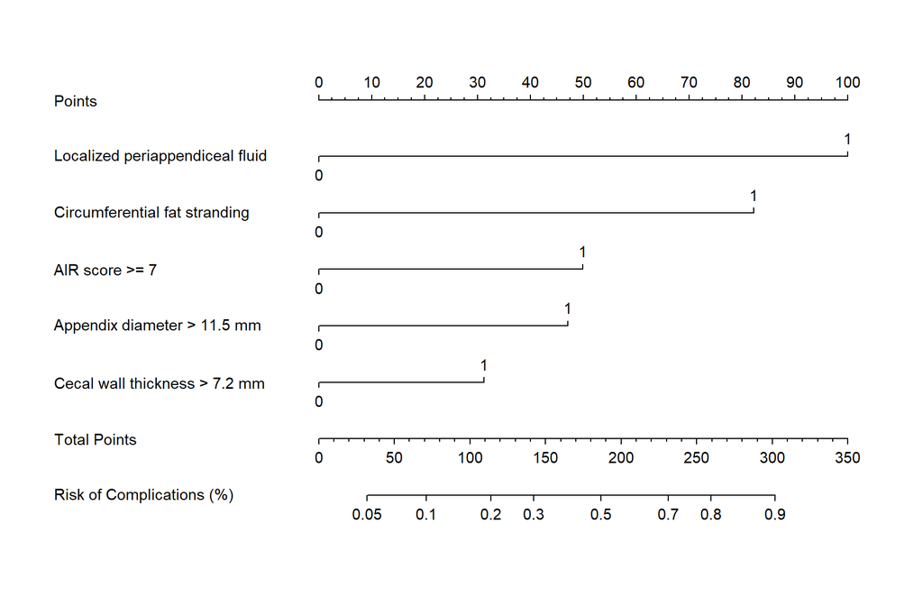

```r
# ==========================================
# 1. NOMOGRAM CONSTRUCTION
# ==========================================
library(rms)
library(Hmisc)

# 1.1 Standardize variable labels for Nomogram display
label(data_clean$dichkhutru) <- "Localized periappendiceal fluid"
label(data_clean$nguongtnm)  <- "Circumferential fat stranding"
label(data_clean$nguongAIR)  <- "AIR score >= 7"
label(data_clean$nguongdkrt) <- "Appendix diameter > 11.5 mm"
label(data_clean$nguongmt)   <- "Cecal wall thickness > 7.2 mm"

# 1.2 Package data environment
dd <- datadist(data_clean)
options(datadist = "dd")

# 1.3 Refit lrm model
fit_rms <- lrm(GPB ~ dichkhutru + nguongtnm + nguongAIR +
                     nguongdkrt + nguongmt,
               data = data_clean,
               x = TRUE, y = TRUE)

# 1.4 Generate Nomogram object
nom <- nomogram(fit_rms,
                fun = function(x) 1/(1+exp(-x)),
                funlabel = "Risk of Complications (%)",
                fun.at = c(0.05, 0.1, 0.2, 0.3, 0.5, 0.7, 0.8, 0.9),
                lp = FALSE)

# 1.5 Visualize Nomogram
plot(nom,
     xfrac = 0.5,        # Adjust left margin ratio for labels
     cex.axis = 0.9,     # Axis label font size ratio
     cex.var = 0.9,      # Variable name font size ratio
     force.label = TRUE)
```

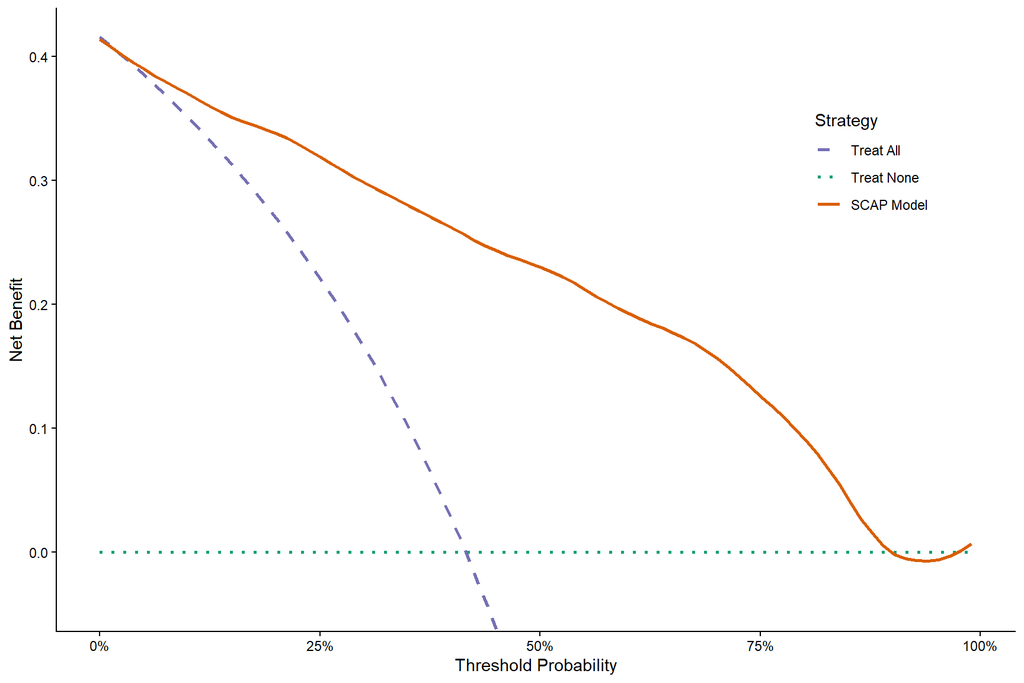

```r
# ==========================================
# 2. DECISION CURVE ANALYSIS (DCA)
# ==========================================
library(dcurves)
library(ggplot2)

# 2.1 Integrate predicted probabilities into the dataset
data_clean$prob_scap <- prob_scap

# 2.2 Perform DCA
dca_res <- dca(GPB ~ prob_scap,
               data = data_clean,
               label = list(prob_scap = "SCAP Model"))

# 2.3 Visualize DCA using ggplot2
plot(dca_res, smooth = TRUE) +
  aes(linetype = label) +

  # Configure color palette and standardize strategy labels
  scale_color_manual(
    name = "Strategy",
    breaks = c("Treat All", "Treat None", "SCAP Model"),
    labels = c("Treat All", "Treat None", "SCAP Model"),
    values = c("Treat All" = "#7570b3", "Treat None" = "#1b9e77", "SCAP Model" = "#d95f02")
  ) +
  scale_linetype_manual(
    name = "Strategy",
    breaks = c("Treat All", "Treat None", "SCAP Model"),
    labels = c("Treat All", "Treat None", "SCAP Model"),
    values = c("Treat All" = "dashed", "Treat None" = "dotted", "SCAP Model" = "solid")
  ) +
  labs(title = NULL,
       x = "Threshold Probability",
       y = "Net Benefit") +
  # Apply minimalistic graphic theme
  theme_classic() +
  # Customize legend coordinates and formatting
  theme(legend.position = c(0.85, 0.75),
        legend.background = element_blank(),
        legend.box.background = element_blank())
```

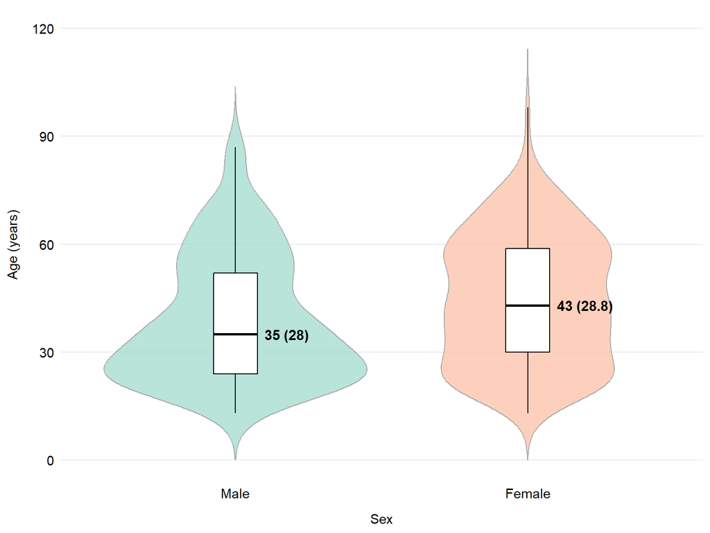

```r
# ==============================================================
# DEMOGRAPHICS: VIOLIN PLOT (AGE & SEX)
# ==============================================================
library(ggplot2)
library(dplyr)

# Extract and label Sex variable
df_violin <- data_clean %>%
  filter(!is.na(gioi) & !is.na(tuoi)) %>%
  mutate(gioi_factor = factor(gioi, levels = c(1, 2), labels = c("Male", "Female")))

# Compute descriptive statistics (Median and IQR)
summary_age <- df_violin %>%
  group_by(gioi_factor) %>%
  summarise(
    median_age = median(tuoi),
    iqr_age = IQR(tuoi)
  ) %>%
  mutate(
    label_text = sprintf("%.0f (%.3g)", median_age, iqr_age)
  )

# Visualize
ggplot(df_violin, aes(x = gioi_factor, y = tuoi, fill = gioi_factor)) +
  geom_violin(trim = FALSE, alpha = 0.7, color = "darkgrey") +
  geom_boxplot(width = 0.15, fill = "white", color = "black",
               outlier.shape = NA, fatten = 2) +
  geom_text(data = summary_age,
            aes(x = gioi_factor, y = median_age, label = label_text),
            nudge_x = 0.1,
            hjust = 0,
            size = 4,
            fontface = "bold") +
  scale_fill_manual(values = c("Male" = "#99d8c9", "Female" = "#fcbba1")) +
  scale_y_continuous(breaks = seq(0, 120, by = 30), limits = c(0, 120)) +
  labs(x = "Sex", y = "Age (years)") +
  theme_minimal() +
  theme(
    legend.position = "none",
    panel.grid.major.x = element_blank(),
    panel.grid.minor = element_blank(),
    axis.title.x = element_text(fontface = "bold", margin = margin(t = 10)),
    axis.title.y = element_text(fontface = "bold", margin = margin(r = 10)),
    axis.text = element_text(color = "black", size = 11)
  )
```

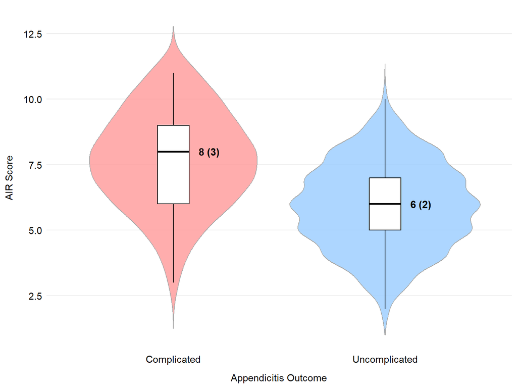

```r
# ==============================================================
# CLINICAL FEATURES: VIOLIN PLOT (AIR SCORE BY OUTCOME)
# ==============================================================

# Extract, label, and order Outcome variable
df_air <- data_clean %>%
  filter(!is.na(GPB) & !is.na(AIR)) %>%
  mutate(GPB_factor = factor(GPB, levels = c(1, 0), labels = c("Complicated", "Uncomplicated")))

# Compute descriptive statistics (Median and IQR)
summary_air <- df_air %>%
  group_by(GPB_factor) %>%
  summarise(
    median_air = median(AIR),
    iqr_air = IQR(AIR)
  ) %>%
  mutate(
    label_text = sprintf("%.0f (%.0f)", median_air, iqr_air)
  )

# Visualize
ggplot(df_air, aes(x = GPB_factor, y = AIR, fill = GPB_factor)) +
  geom_violin(trim = FALSE, alpha = 0.8, color = "darkgrey") +
  geom_boxplot(width = 0.15, fill = "white", color = "black",
               outlier.shape = NA, fatten = 2) +
  geom_text(data = summary_air,
            aes(x = GPB_factor, y = median_air, label = label_text),
            nudge_x = 0.12,
            hjust = 0,
            size = 4,
            fontface = "bold") +
  scale_fill_manual(values = c("Complicated" = "#ff9999", "Uncomplicated" = "#99ccff")) +
  scale_y_continuous(breaks = seq(2.5, 12.5, by = 2.5), limits = c(1, 13)) +
  labs(x = "Appendicitis Outcome", y = "AIR Score") +
  theme_minimal() +
  theme(
    legend.position = "none",
    panel.grid.major.x = element_blank(),
    panel.grid.minor = element_blank(),
    axis.title.x = element_text(fontface = "bold", margin = margin(t = 10)),
    axis.title.y = element_text(fontface = "bold", margin = margin(r = 10)),
    axis.text = element_text(color = "black", size = 11)
  )
```

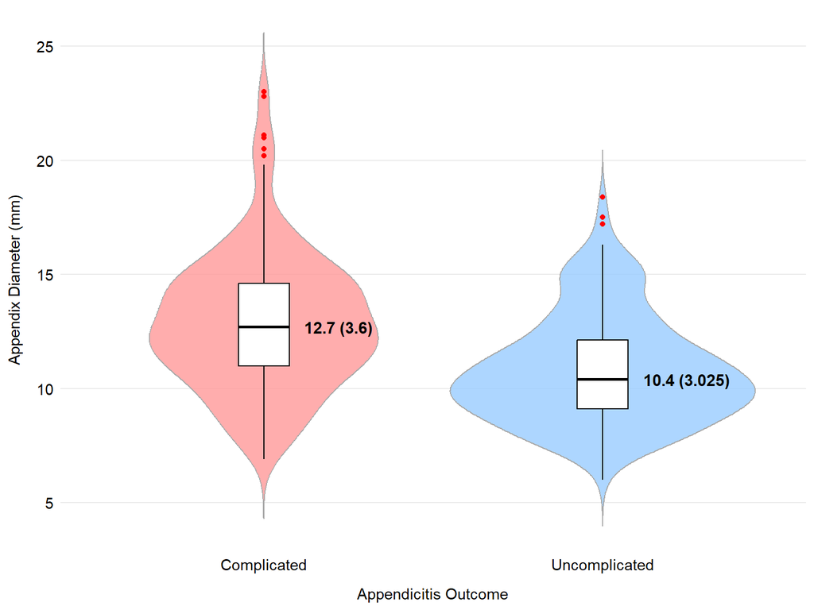

```r
# ==============================================================
# IMAGING FEATURES: VIOLIN PLOT (APPENDIX DIAMETER BY OUTCOME)
# ==============================================================

df_dk <- data_clean %>%
  filter(!is.na(GPB) & !is.na(dkruotthua)) %>%
  mutate(GPB_factor = factor(GPB, levels = c(1, 0), labels = c("Complicated", "Uncomplicated")))

summary_dk <- df_dk %>%
  group_by(GPB_factor) %>%
  summarise(
    median_dk = median(dkruotthua),
    iqr_dk = IQR(dkruotthua)
  ) %>%
  mutate(
    label_text = sprintf("%.1f (%g)", median_dk, iqr_dk)
  )

ggplot(df_dk, aes(x = GPB_factor, y = dkruotthua, fill = GPB_factor)) +
  geom_violin(trim = FALSE, alpha = 0.8, color = "darkgrey") +
  geom_boxplot(width = 0.15, fill = "white", color = "black",
               outlier.color = "red", outlier.shape = 16, outlier.size = 1.5, fatten = 2) +
  geom_text(data = summary_dk,
            aes(x = GPB_factor, y = median_dk, label = label_text),
            nudge_x = 0.12,
            hjust = 0,
            size = 4,
            fontface = "bold") +
  scale_fill_manual(values = c("Complicated" = "#ff9999", "Uncomplicated" = "#99ccff")) +
  scale_y_continuous(breaks = seq(5, 25, by = 5)) +
  labs(x = "Appendicitis Outcome", y = "Appendix Diameter (mm)") +
  theme_minimal() +
  theme(
    legend.position = "none",
    panel.grid.major.x = element_blank(),
    panel.grid.minor = element_blank(),
    axis.title.x = element_text(fontface = "bold", margin = margin(t = 10)),
    axis.title.y = element_text(fontface = "bold", margin = margin(r = 10)),
    axis.text = element_text(color = "black", size = 11)
  )
```

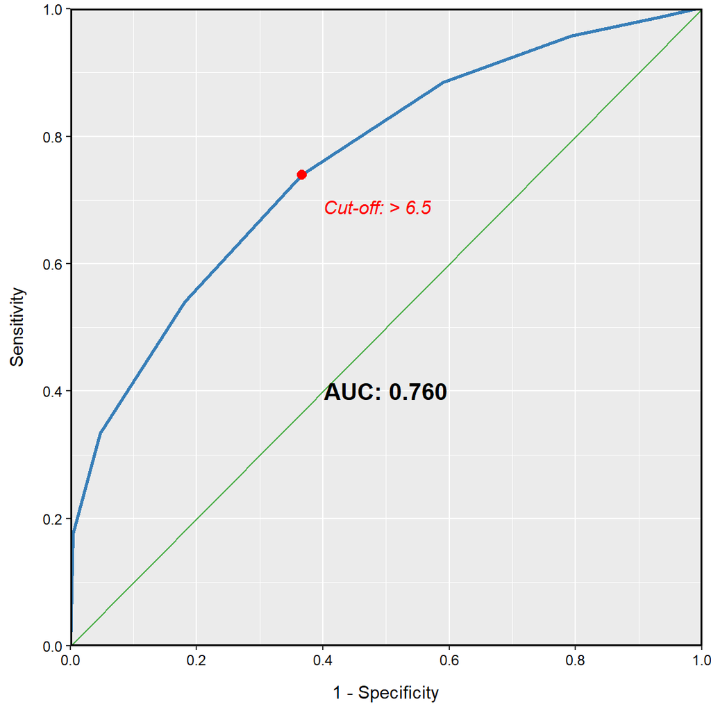

```r
# ==============================================================
# ROC CURVE: AIR SCORE
# ==============================================================
library(pROC)
library(ggplot2)

roc_air <- roc(data_clean$GPB, data_clean$AIR, quiet = TRUE)

roc_data <- data.frame(
  FPR = 1 - roc_air$specificities,
  TPR = roc_air$sensitivities
)

auc_val <- as.numeric(auc(roc_air))
auc_text <- paste0("AUC: ", sprintf("%.3f", auc_val))

# Calculate coordinates for optimal cut-off (6.5)
coord_cutoff <- coords(roc_air, x = 6.5, input = "threshold", ret = c("specificity", "sensitivity"), transpose = FALSE)
cutoff_fpr <- 1 - coord_cutoff$specificity[1]
cutoff_tpr <- coord_cutoff$sensitivity[1]

ggplot(data = roc_data, aes(x = FPR, y = TPR)) +
  geom_abline(intercept = 0, slope = 1, color = "#4daf4a", linewidth = 0.5) +
  geom_line(color = "#377eb8", linewidth = 1) +
  geom_point(x = cutoff_fpr, y = cutoff_tpr, color = "red", size = 2.5) +
  annotate("text", x = cutoff_fpr + 0.12, y = cutoff_tpr - 0.05,
           label = "Cut-off: > 6.5", color = "red", fontface = "italic", size = 4) +
  annotate("text", x = 0.5, y = 0.4,
           label = auc_text, color = "black", fontface = "bold", size = 5) +
  scale_x_continuous(breaks = seq(0, 1, by = 0.2), limits = c(0, 1), expand = c(0, 0)) +
  scale_y_continuous(breaks = seq(0, 1, by = 0.2), limits = c(0, 1), expand = c(0, 0)) +
  labs(x = "1 - Specificity", y = "Sensitivity") +
  theme_gray() +
  theme(
    panel.border = element_rect(color = "black", fill = NA, linewidth = 1),
    axis.title.x = element_text(fontface = "bold", margin = margin(t = 10)),
    axis.title.y = element_text(fontface = "bold", margin = margin(r = 10)),
    axis.text = element_text(color = "black")
  )
```

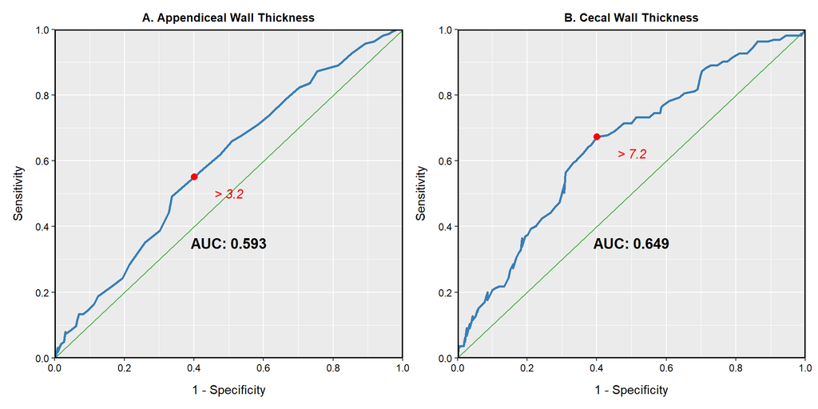

```r
# ==============================================================
# COMBINED ROC CURVES: APPENDICEAL AND CECAL WALL THICKNESS
# ==============================================================
if(!require(patchwork)) install.packages("patchwork")
library(patchwork)

# --- PLOT A: Appendiceal Wall Thickness ---
roc_rt <- roc(data_clean$GPB, data_clean$dthanhruotthua, quiet = TRUE)
data_rt <- data.frame(FPR = 1 - roc_rt$specificities, TPR = roc_rt$sensitivities)
auc_rt <- as.numeric(auc(roc_rt))
auc_text_rt <- paste0("AUC: ", sprintf("%.3f", auc_rt))

coord_rt <- coords(roc_rt, x = 3.2, input = "threshold", ret = c("specificity", "sensitivity"), transpose = FALSE)
fpr_rt <- 1 - coord_rt$specificity[1]
tpr_rt <- coord_rt$sensitivity[1]

plot_a <- ggplot(data = data_rt, aes(x = FPR, y = TPR)) +
  geom_abline(intercept = 0, slope = 1, color = "#4daf4a", linewidth = 0.5) +
  geom_line(color = "#377eb8", linewidth = 1) +
  geom_point(x = fpr_rt, y = tpr_rt, color = "red", size = 2.5) +
  annotate("text", x = fpr_rt + 0.1, y = tpr_rt - 0.05, label = "> 3.2", color = "red", fontface = "italic", size = 4) +
  annotate("text", x = 0.5, y = 0.35, label = auc_text_rt, color = "black", fontface = "bold", size = 4.5) +
  scale_x_continuous(breaks = seq(0, 1, by = 0.2), limits = c(0, 1), expand = c(0, 0)) +
  scale_y_continuous(breaks = seq(0, 1, by = 0.2), limits = c(0, 1), expand = c(0, 0)) +
  labs(title = "A. Appendiceal Wall Thickness", x = "1 - Specificity", y = "Sensitivity") +
  theme_gray() +
  theme(
    plot.title = element_text(face = "bold", hjust = 0.5, size = 10),
    panel.border = element_rect(color = "black", fill = NA, linewidth = 1),
    axis.title.x = element_text(fontface = "bold", margin = margin(t = 10)),
    axis.title.y = element_text(fontface = "bold", margin = margin(r = 10)),
    axis.text = element_text(color = "black")
  )

# --- PLOT B: Cecal Wall Thickness ---
roc_mt <- roc(data_clean$GPB, data_clean$dmanhtrang, quiet = TRUE)
data_mt <- data.frame(FPR = 1 - roc_mt$specificities, TPR = roc_mt$sensitivities)
auc_mt <- as.numeric(auc(roc_mt))
auc_text_mt <- paste0("AUC: ", sprintf("%.3f", auc_mt))

coord_mt <- coords(roc_mt, x = 7.2, input = "threshold", ret = c("specificity", "sensitivity"), transpose = FALSE)
fpr_mt <- 1 - coord_mt$specificity[1]
tpr_mt <- coord_mt$sensitivity[1]

plot_b <- ggplot(data = data_mt, aes(x = FPR, y = TPR)) +
  geom_abline(intercept = 0, slope = 1, color = "#4daf4a", linewidth = 0.5) +
  geom_line(color = "#377eb8", linewidth = 1) +
  geom_point(x = fpr_mt, y = tpr_mt, color = "red", size = 2.5) +
  annotate("text", x = fpr_mt + 0.1, y = tpr_mt - 0.05, label = "> 7.2", color = "red", fontface = "italic", size = 4) +
  annotate("text", x = 0.5, y = 0.35, label = auc_text_mt, color = "black", fontface = "bold", size = 4.5) +
  scale_x_continuous(breaks = seq(0, 1, by = 0.2), limits = c(0, 1), expand = c(0, 0)) +
  scale_y_continuous(breaks = seq(0, 1, by = 0.2), limits = c(0, 1), expand = c(0, 0)) +
  labs(title = "B. Cecal Wall Thickness", x = "1 - Specificity", y = "Sensitivity") +
  theme_gray() +
  theme(
    plot.title = element_text(face = "bold", hjust = 0.5, size = 10),
    panel.border = element_rect(color = "black", fill = NA, linewidth = 1),
    axis.title.x = element_text(fontface = "bold", margin = margin(t = 10)),
    axis.title.y = element_text(fontface = "bold", margin = margin(r = 10)),
    axis.text = element_text(color = "black")
  )

# Display side-by-side
plot_a + plot_b
```

```r
# ==============================================================
# DESCRIPTIVE STATISTICS: CLINICAL AND LABORATORY CHARACTERISTICS
# ==============================================================
if(!require(gtsummary)) install.packages("gtsummary")
library(gtsummary)
library(dplyr)

df_table31 <- data_clean %>%
  select(GPB, gioi, non, dauhcp, sot, phanungdoi, soluongBC, phantramNEU, nguongcrp) %>%
  mutate(GPB = ifelse(GPB == 2, 0, GPB)) %>%
  mutate(
    GPB = factor(GPB, levels = c(1, 0), labels = c("Complicated", "Uncomplicated")),
    gioi = factor(gioi, levels = c(1, 2), labels = c("Male", "Female")),
    non = factor(non, levels = c(1, 2), labels = c("Vomiting", "No vomiting")),
    dauhcp = factor(dauhcp, levels = c(1, 2), labels = c("RLQ pain", "No RLQ pain")),
    sot = factor(sot, levels = c(1, 2), labels = c("Fever", "No fever")),
    phanungdoi = factor(phanungdoi, levels = c(1, 2, 3, 4), labels = c("Mild", "Moderate", "Severe", "None")),
    soluongBC = factor(soluongBC, levels = c(1, 2, 3), labels = c("10 - 14.9 K/mcL", "\u2265 15 K/mcL", "< 10 K/mcL")),
    phantramNEU = factor(phantramNEU, levels = c(1, 2, 3), labels = c("70 - 84%", "\u2265 85%", "< 70%")),
    nguongcrp = factor(nguongcrp, levels = c(1, 2, 3), labels = c("10 - 49 mg/L", "\u2265 50 mg/L", "< 10 mg/L"))
  )

table_31 <- df_table31 %>%
  tbl_summary(
    by = GPB,
    label = list(
      gioi ~ "Sex",
      non ~ "Vomiting",
      dauhcp ~ "Right lower quadrant pain",
      sot ~ "Fever (> 38.5°C)",
      phanungdoi ~ "Rebound tenderness",
      soluongBC ~ "WBC count",
      phantramNEU ~ "Neutrophil percentage",
      nguongcrp ~ "CRP levels"
    ),
    statistic = all_categorical() ~ "{n} ({p}%)",
    digits = all_categorical() ~ c(0, 1),
    missing = "no"
  ) %>%
  add_p(
    test = all_categorical() ~ "chisq.test",
    test.args = all_categorical() ~ list(correct = TRUE),
    pvalue_fun = function(x) style_pvalue(x, digits = 3)
  ) %>%
  modify_header(
    label = "**Variables**",
    stat_1 = "**Complicated**\n**(n={n})**",
    stat_2 = "**Uncomplicated**\n**(n={n})**",
    p.value = "**p-value***"
  ) %>%
  modify_footnote(
    p.value ~ "* p-values computed using Pearson's Chi-squared test with Yates' continuity correction or Fisher's exact test."
  ) %>%
  bold_labels()

table_31
```

**Variables**

**Complicated** **(n=165)**<sup>1</sup>

**Uncomplicated** **(n=232)**<sup>1</sup>

**p-value***<sup>2</sup>

Sex

0.111

Male

81 (49.1%)

94 (40.5%)

Female

84 (50.9%)

138 (59.5%)

Vomiting

0.574

Vomiting

47 (28.5%)

59 (25.4%)

No vomiting

118 (71.5%)

173 (74.6%)

Right lower quadrant pain

0.869

RLQ pain

162 (98.2%)

226 (97.4%)

No RLQ pain

3 (1.8%)

6 (2.6%)

Fever (> 38.5°C)

0.048

Fever

22 (13.3%)

16 (6.9%)

No fever

143 (86.7%)

216 (93.1%)

Rebound tenderness

<0.001

Mild

52 (31.5%)

119 (51.3%)

Moderate

39 (23.6%)

83 (35.8%)

Severe

73 (44.2%)

27 (11.6%)

None

1 (0.6%)

3 (1.3%)

WBC count

0.027

10 - 14.9 K/mcL

64 (38.8%)

114 (49.1%)

≥ 15 K/mcL

72 (43.6%)

71 (30.6%)

< 10 K/mcL

29 (17.6%)

47 (20.3%)

Neutrophil percentage

0.008

70 - 84%

87 (52.7%)

128 (55.2%)

≥ 85%

66 (40.0%)

67 (28.9%)

< 70%

12 (7.3%)

37 (15.9%)

CRP levels

<0.001

10 - 49 mg/L

43 (26.1%)

100 (43.1%)

≥ 50 mg/L

109 (66.1%)

43 (18.5%)

< 10 mg/L

13 (7.9%)

89 (38.4%)

<sup>1</sup> n (%)

<sup>2</sup>

- p-values computed using Pearson’s Chi-squared test with Yates’ continuity correction or Fisher’s exact test.

```r
# ==============================================================
# DESCRIPTIVE STATISTICS: CONTINUOUS VARIABLES
# ==============================================================
df_table32 <- data_clean %>%
  select(GPB, tuoi, crp) %>%
  mutate(
    GPB = ifelse(GPB == 2, 0, GPB),
    GPB = factor(GPB, levels = c(1, 0), labels = c("Complicated", "Uncomplicated"))
  )

table_32 <- df_table32 %>%
  tbl_summary(
    by = GPB,
    label = list(
      tuoi ~ "Age (years)",
      crp ~ "CRP value (mg/L)"
    ),
    type = all_continuous() ~ "continuous",
    statistic = all_continuous() ~ "{median} ({IQR})",
    digits = all_continuous() ~ 1,
    missing = "no"
  ) %>%
  add_p(
    test = all_continuous() ~ "wilcox.test",
    pvalue_fun = function(x) style_pvalue(x, digits = 3)
  ) %>%
  modify_header(
    label = "**Variables**",
    stat_1 = "**Complicated (n={n})**\n**Median (IQR)**",
    stat_2 = "**Uncomplicated (n={n})**\n**Median (IQR)**",
    p.value = "**p-value***"
  ) %>%
  modify_footnote(
    p.value ~ "*Data presented as Median (Interquartile Range); p-values computed using Mann-Whitney U test."
  ) %>%
  bold_labels()

table_32
```

| **Variables** | **Complicated (n=165)** **Median (IQR)**<sup>1</sup> | **Uncomplicated (n=232)** **Median (IQR)**<sup>1</sup> | **p-value***<sup>2</sup> |
| --- | --- | --- | --- |
| Age (years) | 45.0 (31.0) | 36.5 (27.3) | 0.005 |
| CRP value (mg/L) | 85.0 (117.7) | 16.1 (32.7) | <0.001 |

<sup>1</sup> Median (IQR)  
<sup>2</sup> *Data presented as Median (Interquartile Range); p-values computed using Mann-Whitney U test.

```r
# ==============================================================
# INTER-RATER RELIABILITY: COHEN'S KAPPA (CATEGORICAL CT FEATURES)
# ==============================================================
if(!require(irr)) install.packages("irr")
if(!require(vcd)) install.packages("vcd")
if(!require(flextable)) install.packages("flextable")

library(haven)
library(irr)
library(vcd)
library(flextable)

data_icc <- read_sav("D:/NghienCuu/ICC.sav")

var_list <- list(
  c("TNM", "TNMCK2", "Fat stranding severity"),
  c("Matlientuc", "matlientucck2", "Loss of wall continuity"),
  c("daymanhtrang", "daymanhtrangck2", "Cecal wall thickening"),
  c("Batthuockem", "batthuockemck2", "Decreased wall enhancement"),
  c("Khitrong", "khitrongck2", "Intraluminal air"),
  c("Khingoai", "khingoaick2", "Extraluminal air"),
  c("dichkhutru", "dichkhutruck2", "Localized fluid"),
  c("dichtudo", "dichtudock2", "Free fluid"),
  c("hachviem", "hachviemck2", "Lymphadenopathy"),
  c("Tacruot", "tacruotck2", "Small bowel obstruction"),
  c("apxe", "apxeck2", "Periappendiceal abscess"),
  c("Soitrong", "soitrongck2", "Appendicolith"),
  c("Soingoai", "soingoaick2", "Extraluminal appendicolith")
)

results <- data.frame()

for(item in var_list) {
  v1 <- item[1]
  v2 <- item[2]
  name <- item[3]

  df_pair <- data_icc[, c(v1, v2)]
  df_pair <- na.omit(df_pair)

  k_irr <- kappa2(df_pair)
  z_val <- k_irr$statistic
  p_val <- k_irr$p.value

  lvls <- sort(unique(c(df_pair[[1]], df_pair[[2]])))
  f1 <- factor(df_pair[[1]], levels = lvls)
  f2 <- factor(df_pair[[2]], levels = lvls)
  tab <- table(f1, f2)

  k_vcd <- suppressWarnings(Kappa(tab))
  kappa_val <- k_vcd$Unweighted[1]
  se_val <- k_vcd$Unweighted[2]

  ci_lower <- kappa_val - 1.96 * se_val
  ci_upper <- kappa_val + 1.96 * se_val
  if(ci_upper > 1) ci_upper <- 1

  kappa_str <- sprintf("%.2f", kappa_val)
  se_str <- sprintf("%.2f", se_val)
  ci_str <- sprintf("[%0.2f - %0.2f]", ci_lower, ci_upper)
  z_str <- sprintf("%.2f", z_val)
  p_str <- ifelse(p_val < 0.001, "<0.001", sprintf("%.3f", p_val))

  results <- rbind(results, data.frame(
    Feature = name,
    Kappa = kappa_str,
    SE = se_str,
    CI = ci_str,
    Z = z_str,
    p = p_str
  ))
}

table_33 <- results %>%
  flextable() %>%
  set_header_labels(
    Feature = "CT Feature",
    Kappa = "Kappa\nValue",
    SE = "Standard\nError",
    CI = "95% CI",
    Z = "Z Value",
    p = "p-value"
  ) %>%
  bold(part = "header") %>%
  align(j = 1, align = "left", part = "all") %>%
  align(j = 2:6, align = "center", part = "all") %>%
  width(j = 1, width = 2.5) %>%
  width(j = 2:6, width = 1) %>%
  theme_booktabs() %>%
  add_footer_lines("Note: Inter-rater agreement for categorical features evaluated using Cohen's Kappa coefficient (estimated via Z-test).") %>%
  font(fontname = "Arial", part = "all") %>%
  fontsize(size = 10, part = "all")

table_33
```

| CT Feature | Kappa Value | Standard Error | 95% CI | Z Value | p-value |
| --- | --- | --- | --- | --- | --- |
| Fat stranding severity | 0.90 | 0.07 | [0.76 - 1.00] | 5.72 | <0.001 |
| Loss of wall continuity | 0.69 | 0.14 | [0.41 - 0.97] | 4.41 | <0.001 |
| Cecal wall thickening | 0.91 | 0.09 | [0.73 - 1.00] | 5.77 | <0.001 |
| Decreased wall enhancement | 0.58 | 0.13 | [0.33 - 0.84] | 3.72 | <0.001 |
| Intraluminal air | 0.88 | 0.08 | [0.72 - 1.00] | 5.57 | <0.001 |
| Extraluminal air | 1.00 | 0.00 | [1.00 - 1.00] | 6.32 | <0.001 |
| Localized fluid | 0.75 | 0.10 | [0.55 - 0.95] | 4.75 | <0.001 |
| Free fluid | 0.90 | 0.07 | [0.76 - 1.00] | 5.69 | <0.001 |
| Lymphadenopathy | 0.67 | 0.12 | [0.43 - 0.90] | 4.47 | <0.001 |
| Small bowel obstruction | 1.00 | 0.00 | [1.00 - 1.00] | 6.32 | <0.001 |
| Periappendiceal abscess | 0.72 | 0.18 | [0.37 - 1.00] | 4.76 | <0.001 |
| Appendicolith | 0.89 | 0.08 | [0.74 - 1.00] | 5.67 | <0.001 |
| Extraluminal appendicolith | 1.00 | 0.00 | [1.00 - 1.00] | 6.32 | <0.001 |

Note: Inter-rater agreement for categorical features evaluated using Cohen's Kappa coefficient (estimated via Z-test).

```r
# ==============================================================
# INTER-RATER RELIABILITY: ICC (CONTINUOUS CT FEATURES)
# ==============================================================
library(irr)
library(flextable)

var_list_icc <- list(
  c("dkruotthua", "dkrtck2", "Appendix diameter"),
  c("dthanhruotthua", "drtck2", "Appendiceal wall thickness"),
  c("dmanhtrang", "dmtck2", "Cecal wall thickness")
)

results_icc <- data.frame()

for(item in var_list_icc) {
  v1 <- item[1]
  v2 <- item[2]
  name <- item[3]

  df_pair <- data_icc[, c(v1, v2)]
  df_pair <- na.omit(df_pair)

  icc_single <- icc(df_pair, model = "twoway", type = "agreement", unit = "single")
  icc_avg <- icc(df_pair, model = "twoway", type = "agreement", unit = "average")

  val_s <- sprintf("%.2f", icc_single$value)
  ci_s <- sprintf("%.2f - %.2f", icc_single$lbound, icc_single$ubound)

  val_a <- sprintf("%.2f", icc_avg$value)
  ci_a <- sprintf("%.2f - %.2f", icc_avg$lbound, icc_avg$ubound)

  results_icc <- rbind(results_icc, data.frame(
    Test = name,
    ICC_don = val_s,
    KTC_don = ci_s,
    ICC_tb = val_a,
    KTC_tb = ci_a
  ))
}

table_34 <- results_icc %>%
  flextable() %>%
  set_header_labels(
    Test = "Variable",
    ICC_don = "Single ICC",
    KTC_don = "95% CI",
    ICC_tb = "Average ICC",
    KTC_tb = "95% CI"
  ) %>%
  bold(part = "header") %>%
  align(j = 1, align = "left", part = "all") %>%
  align(j = 2:5, align = "center", part = "all") %>%
  width(j = 1, width = 2.2) %>%
  width(j = 2:5, width = 1.2) %>%
  theme_booktabs() %>%
  add_footer_lines("Note: p < 0.001 for all Intraclass Correlation Coefficient (ICC) F-tests.") %>%
  italic(part = "footer") %>%
  font(fontname = "Arial", part = "all") %>%
  fontsize(size = 10, part = "all")

table_34
```

| Variable | Single ICC | 95% CI | Average ICC | 95% CI |
| --- | --- | --- | --- | --- |
| Appendix diameter | 0.97 | 0.93 - 0.98 | 0.98 | 0.96 - 0.99 |
| Appendiceal wall thickness | 0.98 | 0.94 - 0.99 | 0.99 | 0.97 - 0.99 |
| Cecal wall thickness | 0.99 | 0.98 - 0.99 | 0.99 | 0.99 - 1.00 |

Note: p < 0.001 for all Intraclass Correlation Coefficient (ICC) F-tests.

```r
# ==============================================================
# UNIVARIABLE LOGISTIC REGRESSION: CT IMAGING FEATURES
# ==============================================================
if(!require(logistf)) install.packages("logistf")
library(gtsummary)
library(dplyr)
library(flextable)
library(logistf)

df_uv_ct <- data_clean %>%
  select(GPB, tttnm, nguongtnm, Khitrong, Soitrong, hachviem, dichkhutru, dichtudo) %>%
  mutate(
    GPB_factor = factor(ifelse(GPB %in% c(1), 1, 0), levels = c(1, 0), labels = c("Complicated", "Uncomplicated")),
    GPB_num = ifelse(GPB %in% c(1), 1, 0),

    tttnm_cat = factor(ifelse(tttnm %in% c(1), "Present", "Absent"), levels = c("Absent", "Present")),
    nguongtnm_cat = factor(ifelse(nguongtnm %in% c(1), "Present", "Absent"), levels = c("Absent", "Present")),
    Khitrong_cat = factor(ifelse(Khitrong %in% c(1), "Present", "Absent"), levels = c("Absent", "Present")),
    Soitrong_cat = factor(ifelse(Soitrong %in% c(1), "Present", "Absent"), levels = c("Absent", "Present")),
    hachviem_cat = factor(ifelse(hachviem %in% c(1), "Present", "Absent"), levels = c("Absent", "Present")),
    dichkhutru_cat = factor(ifelse(dichkhutru %in% c(1), "Present", "Absent"), levels = c("Absent", "Present")),
    dichtudo_cat = factor(ifelse(dichtudo %in% c(1), "Present", "Absent"), levels = c("Absent", "Present"))
  )

# Frequencies
t1_counts_ct <- df_uv_ct %>%
  select(GPB_factor, tttnm_cat, nguongtnm_cat, Khitrong_cat, Soitrong_cat, hachviem_cat, dichkhutru_cat, dichtudo_cat) %>%
  tbl_summary(
    by = GPB_factor,
    type = list(everything() ~ "dichotomous"),
    value = list(everything() ~ "Present"),
    label = list(
      tttnm_cat ~ "Any fat stranding*",
      nguongtnm_cat ~ "Circumferential fat stranding",
      Khitrong_cat ~ "Intraluminal air",
      Soitrong_cat ~ "Appendicolith",
      hachviem_cat ~ "Lymphadenopathy",
      dichkhutru_cat ~ "Localized periappendiceal fluid",
      dichtudo_cat ~ "Free fluid"
    ),
    statistic = all_categorical() ~ "{n} ({p}%)",
    digits = all_categorical() ~ c(0, 1)
  )

# Firth's Penalized Likelihood Regression (To handle complete separation)
t2_firth <- df_uv_ct %>%
  select(GPB_num, tttnm_cat) %>%
  tbl_uvregression(
    method = logistf,
    y = GPB_num,
    exponentiate = TRUE,
    hide_n = TRUE,
    show_single_row = everything(),
    label = list(tttnm_cat ~ "Any fat stranding*")
  )

# Standard Binary Logistic Regression
t2_glm <- df_uv_ct %>%
  select(GPB_num, nguongtnm_cat, Khitrong_cat, Soitrong_cat, hachviem_cat, dichkhutru_cat, dichtudo_cat) %>%
  tbl_uvregression(
    method = glm,
    y = GPB_num,
    method.args = list(family = binomial),
    exponentiate = TRUE,
    hide_n = TRUE,
    show_single_row = everything(),
    label = list(
      nguongtnm_cat ~ "Circumferential fat stranding",
      Khitrong_cat ~ "Intraluminal air",
      Soitrong_cat ~ "Appendicolith",
      hachviem_cat ~ "Lymphadenopathy",
      dichkhutru_cat ~ "Localized periappendiceal fluid",
      dichtudo_cat ~ "Free fluid"
    ),
    pvalue_fun = function(x) style_pvalue(x, digits = 3)
  )

# Merge
t2_combined <- tbl_stack(list(t2_firth, t2_glm))
```

```
## Table 1 Column Name   Header
## label                 "**Characteristic**"
## estimate              "**exp(Beta)**"
## conf.low              "**95% CI**"
## p.value               "**p-value**"
## Table 2 Column Name   Header
## label                 "**Characteristic**"
## estimate              "**OR**"
## conf.low              "**95% CI**"
## p.value               "**p-value**"
```

```r
table_311 <- tbl_merge(
  tbls = list(t1_counts_ct, t2_combined),
  tab_spanner = FALSE
) %>%
  modify_header(
    label = "**CT Feature**",
    stat_1_1 = "**Complicated**\n**(n={n})**",
    stat_2_1 = "**Uncomplicated**\n**(n={n})**",
    estimate_2 = "**OR**",
    ci_2 = "**95% CI**",
    p.value_2 = "**p-value**"
  ) %>%
  modify_column_hide(columns = any_of(c("ci_1", "ci_2_1", "ci_1_2", "conf.low", "conf.high", "p.value_1"))) %>%
  modify_footnote(
    everything() ~ NA,
    p.value_2 ~ "*OR and 95% CI estimated via Firth's penalized likelihood approach. Other variables were analyzed using standard binary logistic regression."
  ) %>%
  bold_labels() %>%
  as_flex_table() %>%
  italic(part = "footer")

table_311
```

| CT Feature | Complicated (n=165) | Uncomplicated (n=232) | OR | 95% CI | 95% CI | p-value1 |
| --- | --- | --- | --- | --- | --- | --- |
| Any fat stranding* | 165 (100.0%) | 213 (91.8%) | 30.2 | 4.10, 3,857 | 4.10, 3,857 | <0.001 |
| Circumferential fat stranding | 116 (70.3%) | 36 (15.5%) | 12.9 | 8.00, 21.2 | 8.00, 21.2 | <0.001 |
| Intraluminal air | 62 (37.6%) | 50 (21.6%) | 2.19 | 1.41, 3.43 | 1.41, 3.43 | <0.001 |
| Appendicolith | 81 (49.1%) | 76 (32.8%) | 1.98 | 1.32, 2.99 | 1.32, 2.99 | 0.001 |
| Lymphadenopathy | 115 (69.7%) | 128 (55.2%) | 1.87 | 1.23, 2.86 | 1.23, 2.86 | 0.004 |
| Localized periappendiceal fluid | 148 (89.7%) | 83 (35.8%) | 15.6 | 9.06, 28.4 | 9.06, 28.4 | <0.001 |
| Free fluid | 100 (60.6%) | 87 (37.5%) | 2.56 | 1.71, 3.88 | 1.71, 3.88 | <0.001 |

1*OR and 95% CI estimated via Firth's penalized likelihood approach. Other variables were analyzed using standard binary logistic regression.  
Abbreviations: CI = Confidence Interval, OR = Odds Ratio

```r
# ==============================================================
# FINAL MULTIVARIABLE LOGISTIC REGRESSION MODEL (SCAP)
# ==============================================================
if(!require(broom)) install.packages("broom")
library(dplyr)
library(broom)
library(flextable)

# Initialize dataset for reduced model
df_scap <- data_clean %>%
  mutate(
    GPB_num = ifelse(GPB %in% c(1), 1, 0),
    dichkhutru_cat = factor(ifelse(dichkhutru %in% c(1), "Present", "Absent"), levels = c("Absent", "Present")),
    nguongtnm_cat  = factor(ifelse(nguongtnm %in% c(1), "Present", "Absent"), levels = c("Absent", "Present")),
    AIR_cat        = factor(ifelse(nguongAIR %in% c(1), "Present", "Absent"), levels = c("Absent", "Present")),
    dkrt_cat       = factor(ifelse(dkruotthua > 11.5, "Present", "Absent"), levels = c("Absent", "Present")),
    mt_cat         = factor(ifelse(dmanhtrang > 7.2, "Present", "Absent"), levels = c("Absent", "Present"))
  )

fit_scap <- glm(GPB_num ~ dichkhutru_cat + nguongtnm_cat + AIR_cat + dkrt_cat + mt_cat,
                data = df_scap, family = binomial)

# Profile Likelihood 95% Confidence Intervals
ci_scap <- confint(fit_scap)

res_scap <- tidy(fit_scap) %>%
  mutate(
    conf.low = ci_scap[, 1],
    conf.high = ci_scap[, 2],
    OR_val = exp(estimate),
    CI_low = exp(conf.low),
    CI_high = exp(conf.high),

    HeSo = sprintf("%.2f", estimate),
    aOR = sprintf("%.2f", OR_val),
    KTC = paste0(sprintf("%.2f", CI_low), " - ", sprintf("%.2f", CI_high)),
    p = ifelse(p.value < 0.001, "< 0.001", sprintf("%.3f", p.value))
  )

res_scap <- res_scap %>%
  mutate(
    aOR = ifelse(term == "(Intercept)", "", aOR),
    KTC = ifelse(term == "(Intercept)", "", KTC),
    p = ifelse(term == "(Intercept)", "", p),

    DacDiem = case_when(
      term == "dichkhutru_catPresent" ~ "Localized fluid",
      term == "nguongtnm_catPresent"  ~ "Circumferential fat stranding",
      term == "AIR_catPresent"        ~ "AIR score \u2265 7",
      term == "dkrt_catPresent"       ~ "Appendix diameter > 11.5 mm",
      term == "mt_catPresent"         ~ "Cecal wall thickness > 7.2 mm",
      term == "(Intercept)"           ~ "Intercept",
      TRUE ~ term
    )
  ) %>%
  select(DacDiem, HeSo, aOR, KTC, p) %>%
  arrange(match(DacDiem, c("Localized fluid", "Circumferential fat stranding",
                           "AIR score \u2265 7", "Appendix diameter > 11.5 mm",
                           "Cecal wall thickness > 7.2 mm", "Intercept")))

table_319 <- flextable(res_scap) %>%
  set_header_labels(
    DacDiem = "Variable",
    HeSo = "Coefficient (\u03B2)",
    aOR = "Adjusted OR",
    KTC = "95% CI",
    p = "p-value"
  ) %>%
  bold(part = "header") %>%
  align(j = 1, align = "left", part = "all") %>%
  align(j = 2:5, align = "center", part = "all") %>%
  width(j = 1, width = 2.4) %>%
  width(j = 2:5, width = 1.0) %>%
  theme_booktabs() %>%
  add_footer_lines("Note: Adjusted Odds Ratios (aOR), 95% CIs, and p-values derived from multivariable logistic regression after backward elimination.") %>%
  italic(part = "footer") %>%
  font(fontname = "Arial", part = "all") %>%
  fontsize(size = 10, part = "all")

table_319
```

| Variable | Coefficient (β) | Adjusted OR | 95% CI | p-value |
| --- | --- | --- | --- | --- |
| Localized fluid | 1.90 | 6.72 | 3.61 - 13.01 | < 0.001 |
| Circumferential fat stranding | 1.57 | 4.78 | 2.72 - 8.51 | < 0.001 |
| AIR score ≥ 7 | 0.95 | 2.59 | 1.48 - 4.56 | < 0.001 |
| Appendix diameter > 11.5 mm | 0.90 | 2.45 | 1.42 - 4.25 | 0.001 |
| Cecal wall thickness > 7.2 mm | 0.59 | 1.81 | 1.03 - 3.18 | 0.038 |
| Intercept | -3.55 |  |  |  |

Note: Adjusted Odds Ratios (aOR), 95% CIs, and p-values derived from multivariable logistic regression after backward elimination.

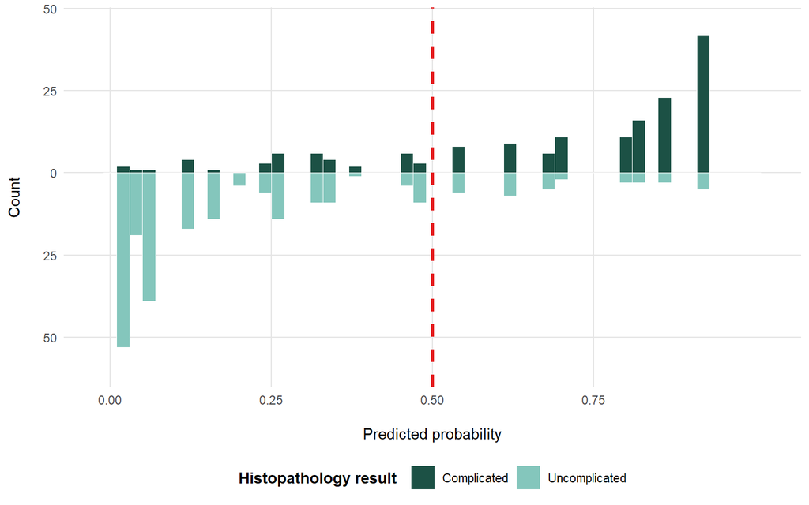

```r
# ==============================================================
# MIRROR HISTOGRAM: PREDICTED PROBABILITY DISTRIBUTION
# ==============================================================
library(dplyr)
library(ggplot2)

prob_preds <- predict(fit_scap, type = "response")

df_plot <- data.frame(
  XacSuat = prob_preds,
  GPB_thucte = factor(fit_scap$y,
                      levels = c(0, 1),
                      labels = c("Uncomplicated", "Complicated"))
)

plot_37 <- ggplot(df_plot, aes(x = XacSuat, fill = GPB_thucte)) +
  geom_histogram(data = filter(df_plot, GPB_thucte == "Complicated"),
                 aes(y = after_stat(count)),
                 binwidth = 0.02, color = "white", linewidth = 0.2) +
  geom_histogram(data = filter(df_plot, GPB_thucte == "Uncomplicated"),
                 aes(y = -after_stat(count)),
                 binwidth = 0.02, color = "white", linewidth = 0.2) +
  geom_vline(xintercept = 0.5, color = "#e41a1c", linetype = "dashed", linewidth = 1.2) +
  scale_fill_manual(values = c(
    "Uncomplicated" = "#84c6bc",
    "Complicated" = "#1c5145"
  )) +
  scale_y_continuous(
    breaks = seq(-75, 75, by = 25),
    labels = abs,
    limits = c(-60, 45)
  ) +
  scale_x_continuous(
    breaks = c(0, 0.25, 0.5, 0.75),
    labels = c("0.00", "0.25", "0.50", "0.75"),
    limits = c(-0.02, 1.02)
  ) +
  labs(
    x = "Predicted probability",
    y = "Count",
    fill = "Histopathology result"
  ) +
  theme_minimal() +
  theme(
    legend.position = "bottom",
    legend.title = element_text(face = "bold", margin = margin(r = 10)),
    axis.title.x = element_text(margin = margin(t = 15)),
    axis.title.y = element_text(margin = margin(r = 15)),
    panel.grid.minor = element_blank(),
    panel.grid.major.x = element_line(color = "grey90"),
    panel.grid.major.y = element_line(color = "grey90")
  )

plot_37
```